# Bayesian modeling and prediction for movies

Rotten Tomatoes and IMDB are the two most trusted source to measure the performance and quality of movie. Rotten Tomatoes introduced one model as Tomatometer as trusted measurement of the quality of the entertainment. This is based on user provided rating, reviews of millions of users on different TV shows, feature flims and TV movies. Rotten Tomatoes designates the best reviewed movies and TV shows as Certified Fresh. That accolade is awarded with Tomatometer ratings of 75% and higher, and a required minimum number of reviews.

### What is the Tomatometer?

The Tomatometer rating - based on the published opinions of hundreds of film and television critics - is a trusted measurement of movie and TV programming quality for millions of moviegoers. The Tomatometer rating represents the percentage of professional critic reviews that are positive for a given film or television show. Back in the days of the open theaters, when a play was particularly atrocious, the audience expressed their dissatisfaction by not only booing and hissing at the stage, but throwing whatever was at hand – vegetables and fruits included.

->The full popcorn bucket means the movie received 3.5 stars or higher by Flixster and Rotten Tomatoes users. ->The tipped over popcorn bucket means the movie received less than 3.5 stars by Flixster and Rotten Tomatoes users. ->The plus sign will appear for movies that do not have audience ratings or reviews. The percentage you see associated with this icon is the percentage of users who added the movie to their Want-to-See list.

### What is the audience score?

The Audience rating, denoted by a popcorn bucket, is the percentage of all Flixster.com and RottenTomatoes.com users who have rated the movie or TV Show positively.

->A good review is denoted by a fresh red tomato. In order for a movie or TV show to receive an overall rating of Fresh, the reading on the Tomatometer for that movie must be at least 60%.

->A bad review is denoted by a rotten green tomato splat (59% or less).

->To receive a Certified Fresh rating a movie must have a steady Tomatometer rating of 75% or better. Movies opening in wide release need at least 80 reviews from Tomatometer Critics (including 5 Top Critics). Movies opening in limited release need at least 40 reviews from Tomatometer Critics (including 5 Top Critics). A TV show must have a Tomatometer Score of 75% or better with 20 or more reviews from Tomatometer Critics (including 5 Top Critics). If the Tomatometer score drops below 70%, then the movie or TV show loses its Certified Fresh status. In some cases, the Certified Fresh designation may be held at the discretion of the Rotten Tomatoes editorial team.

### Data Collection

Main source of these data is crowd sourcing. Though it started as a hobby project but now it became the most trusted source of celebrity content, authoritative source for movie and TV shows.

Though they are mostly dependend on crowd sourcing but their content gets feed from different news feeds and data sources. But they they have a strong content review model and technical facilities to valided those contents and focus on reliable sources.

##### Data Source and further information link

Dataset: [Data Set] https://d3c33hcgiwev3.cloudfront.net/_e1fe0c85abec6f73c72d73926884eaca_movies.Rdata?Expires=1502150400&Signature=bRT93uon8xdCRVyQoTb2jNM1qjl7nGY4Tqr5BMAv57V4B1xKAAVZsJrQlXADbzZhBcFJuxwz2cixNHvlKHpXV28CSBbMDv5gTRTXakMfh1d5DsAr~PoW~AKh6R4kp3POdCWmJSGvIm-Er8dQtWc5LJk61oPQvCKVWi-RBb6vWBs_&Key-Pair-Id=APKAJLTNE6QMUY6HBC5A

Codebook: Movies Codebook

##### source information

Rotten Tomatoes: [Rotten Tomatoes](https://www.rottentomatoes.com/)

IMDB: [IMDB](http://www.imdb.com/)

Generalizability

The present data were derived from an observational study. The data set is comprised of 651 randomly sampled movies produced and released from 1970 to 2014. According to IMDb, there have 9,962 movies been release from 1972 to 2016 so that the 10% condition (9,962*10% = 996) is met. Since the sampling size is large enough and less than 10% of population, it can assume that the random sampling is conducted. Therefore we can conclude that the sample is indeed generalizable to the entire population. Causality

The data cannot be used to establish a causal relation between the variables of interest as there was no random assignment to the explanatory and independent variables.

## Setup

### Load packages

```r
library(ggplot2)
library(dplyr)
library(statsr)
library(BAS)
library("tidyr")
library('GGally')
library('knitr')
library('grid')
library('gridExtra')
library('MASS')
source('Utilities.R')
# apply general knitr options
knitr::opts_chunk$set(comment=NA, fig.align='center')
```

### Load data

```r
#load("movies.Rdata")
load("imdbdata.gz")
data <- movies
```

## Part 1: Data

At starting we will perform a intial check on the dimensions of the dataset and the properties of the data.

```r
dim(data)
```

```
[1] 651  32
```

```r
str(data)
```

```
Classes 'tbl_df', 'tbl' and 'data.frame':   651 obs. of  32 variables:
 $ title           : chr  "Filly Brown" "The Dish" "Waiting for Guffman" "The Age of Innocence" ...
 $ title_type      : Factor w/ 3 levels "Documentary",..: 2 2 2 2 2 1 2 2 1 2 ...
 $ genre           : Factor w/ 11 levels "Action & Adventure",..: 6 6 4 6 7 5 6 6 5 6 ...
 $ runtime         : num  80 101 84 139 90 78 142 93 88 119 ...
 $ mpaa_rating     : Factor w/ 6 levels "G","NC-17","PG",..: 5 4 5 3 5 6 4 5 6 6 ...
 $ studio          : Factor w/ 211 levels "20th Century Fox",..: 91 202 167 34 13 163 147 118 88 84 ...
 $ thtr_rel_year   : num  2013 2001 1996 1993 2004 ...
 $ thtr_rel_month  : num  4 3 8 10 9 1 1 11 9 3 ...
 $ thtr_rel_day    : num  19 14 21 1 10 15 1 8 7 2 ...
 $ dvd_rel_year    : num  2013 2001 2001 2001 2005 ...
 $ dvd_rel_month   : num  7 8 8 11 4 4 2 3 1 8 ...
 $ dvd_rel_day     : num  30 28 21 6 19 20 18 2 21 14 ...
 $ imdb_rating     : num  5.5 7.3 7.6 7.2 5.1 7.8 7.2 5.5 7.5 6.6 ...
 $ imdb_num_votes  : int  899 12285 22381 35096 2386 333 5016 2272 880 12496 ...
```

[output cut: 18 more lines]

```r
summary(data)
```

```
    title                  title_type                 genre
 Length:651         Documentary : 55   Drama             :305
 Class :character   Feature Film:591   Comedy            : 87
 Mode  :character   TV Movie    :  5   Action & Adventure: 65
                                       Mystery & Suspense: 59
                                       Documentary       : 52
                                       Horror            : 23
                                       (Other)           : 60
    runtime       mpaa_rating                               studio
 Min.   : 39.0   G      : 19   Paramount Pictures              : 37
 1st Qu.: 92.0   NC-17  :  2   Warner Bros. Pictures           : 30
 Median :103.0   PG     :118   Sony Pictures Home Entertainment: 27
 Mean   :105.8   PG-13  :133   Universal Pictures              : 23
 3rd Qu.:115.8   R      :329   Warner Home Video               : 19
 Max.   :267.0   Unrated: 50   (Other)                         :507
 NA's   :1                     NA's                            :  8
 thtr_rel_year  thtr_rel_month   thtr_rel_day    dvd_rel_year
 Min.   :1970   Min.   : 1.00   Min.   : 1.00   Min.   :1991
 1st Qu.:1990   1st Qu.: 4.00   1st Qu.: 7.00   1st Qu.:2001
 Median :2000   Median : 7.00   Median :15.00   Median :2004
 Mean   :1998   Mean   : 6.74   Mean   :14.42   Mean   :2004
 3rd Qu.:2007   3rd Qu.:10.00   3rd Qu.:21.00   3rd Qu.:2008
 Max.   :2014   Max.   :12.00   Max.   :31.00   Max.   :2015
                                                NA's   :8
 dvd_rel_month     dvd_rel_day     imdb_rating    imdb_num_votes
 Min.   : 1.000   Min.   : 1.00   Min.   :1.900   Min.   :   180
 1st Qu.: 3.000   1st Qu.: 7.00   1st Qu.:5.900   1st Qu.:  4546
 Median : 6.000   Median :15.00   Median :6.600   Median : 15116
 Mean   : 6.333   Mean   :15.01   Mean   :6.493   Mean   : 57533
 3rd Qu.: 9.000   3rd Qu.:23.00   3rd Qu.:7.300   3rd Qu.: 58301
 Max.   :12.000   Max.   :31.00   Max.   :9.000   Max.   :893008
 NA's   :8        NA's   :8
         critics_rating critics_score    audience_rating audience_score
 Certified Fresh:135    Min.   :  1.00   Spilled:275     Min.   :11.00
 Fresh          :209    1st Qu.: 33.00   Upright:376     1st Qu.:46.00
 Rotten         :307    Median : 61.00                   Median :65.00
                        Mean   : 57.69                   Mean   :62.36
                        3rd Qu.: 83.00                   3rd Qu.:80.00
                        Max.   :100.00                   Max.   :97.00

```

[output cut: 13 more lines]

```



    actor3             actor4             actor5
 Length:651         Length:651         Length:651
 Class :character   Class :character   Class :character
 Mode  :character   Mode  :character   Mode  :character




   imdb_url            rt_url
 Length:651         Length:651
 Class :character   Class :character
 Mode  :character   Mode  :character
```

## Part 2: Data manipulation

### Part2 : Data Manipulation

Recommended features has been derived in the following code snippet.

```r
# reasign yes or no to feature oscar_season, where release month is either  "10", "11", "12"
data <- data %>% mutate(oscar_season = as.factor(ifelse(thtr_rel_month %in% c('10', '11', '12'), 'yes', 'no')))

# reasign yes or no to feature summer_season, where release month is either  "6", "7", "8"
data <- data %>% mutate(summer_season = as.factor(ifelse(thtr_rel_month %in% c('6', '7', '8'), 'yes', 'no')))

# reasign yes or no to feature mpaa_rating_R, where mpaa_rating is "R"
data <- data %>% mutate(mpaa_rating_R = as.factor(ifelse(mpaa_rating == 'R', 'yes', 'no')))

# reasign yes or no to feature drama, where genre is "drama"
data <- data %>% mutate(drama = as.factor(ifelse(genre ==  'Drama', 'yes', 'no')))

# reasign yes or no to feature feature_film, where title_type is "Feature Film"
data <- data %>% mutate(feature_film = as.factor(ifelse(title_type ==  'Feature Film', 'yes', 'no')))


dim(data)
```

```
[1] 651  37
```

Do current dataset contains 37 coloumns where we have 5 derived features to make our model robust and strong.

## Part 3: Exploratory data analysis

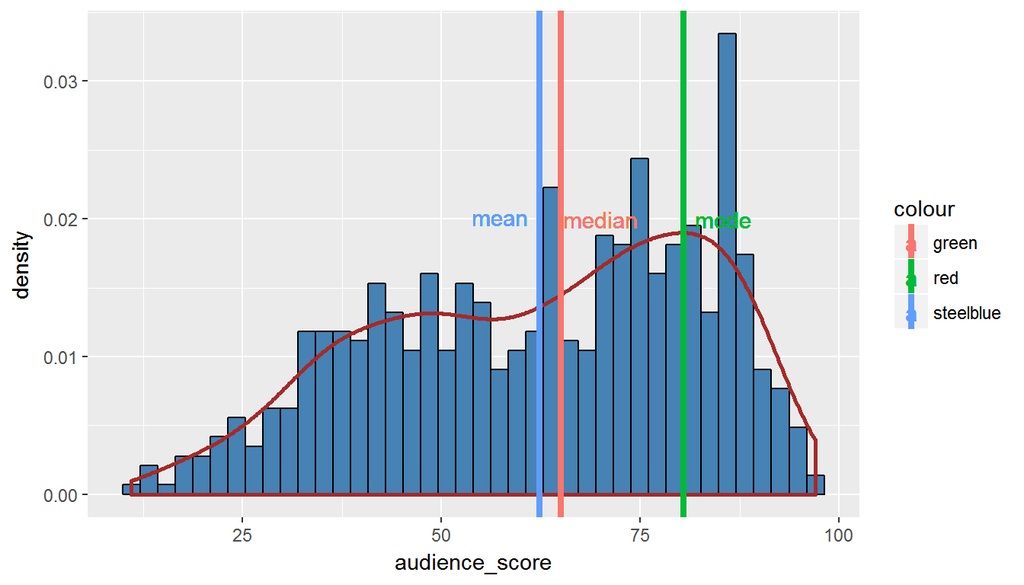

```r
  features <- c('audience_score', 'oscar_season', 'summer_season', 'mpaa_rating_R', 'drama', 'feature_film' )

  # Create a new dataset to explicitely show dataset containing NA's
  data.analysis <- data[, features]

  # remove NA's
  data.analysis <- data.analysis[complete.cases(data.analysis), ]

  # calculate the mode of the distribution
  mode <- dmode(data.analysis$audience_score)

  ggplot(data = data.analysis, aes(x = audience_score, y = ..density..)) +
  geom_histogram(bins = 40, fill = 'steelblue', colour = 'black') + #bdbdbd
  geom_density(size = 1, colour = 'brown') + #cccccc
  geom_vline(data = data, mapping = aes( xintercept = mean(data$audience_score),
             colour = 'steelblue', show_guide = F ), size = 1.5) +
  geom_vline(data = data,mapping = aes( xintercept = median(data$audience_score),
             colour = 'green', show_guide = F), size = 1.5) +
  geom_vline(data = data, mapping = aes( xintercept = mode, colour = 'red', show_guide = F),
             size = 1.5) +
  geom_text(data = data, aes( x = (mean(data$audience_score) - 5), y = .020, label = 'mean',
            colour = 'steelblue'), size = 4, parse = T) +
  geom_text(data = data,aes( x = (median(data$audience_score) + 5),y = .020,  label = 'median',
            colour = 'green'), size = 4, parse = T) +
  geom_text(data = data, aes( x = (mode + 5), y = .020, label = 'mode', colour = 'red'),
            size = 4, parse = T)
```

```r
  mean(data.analysis$audience_score)
```

```
[1] 62.36252
```

```r
  median(data.analysis$audience_score)
```

```
[1] 65
```

```r
  mode
```

```
[1] 80.42094
```

```r
  summary(data.analysis$audience_score)
```

```
   Min. 1st Qu.  Median    Mean 3rd Qu.    Max.
  11.00   46.00   65.00   62.36   80.00   97.00
```

```r
  IQR(data.analysis$audience_score)
```

```
[1] 34
```

These plots represents analysis and relationship of the audience score with other features.

## Analysis of the newly created features

These part represents analysis of the 5 derived features from the dataset.We’ll have a look at the newly created features oscar_season, summer_season, mpaa_rating_R, drama and feature_film. We create a boxplot for each feature, comparing them with the audience_score. We will also analyse the variability of the new features by comparing them to each other.

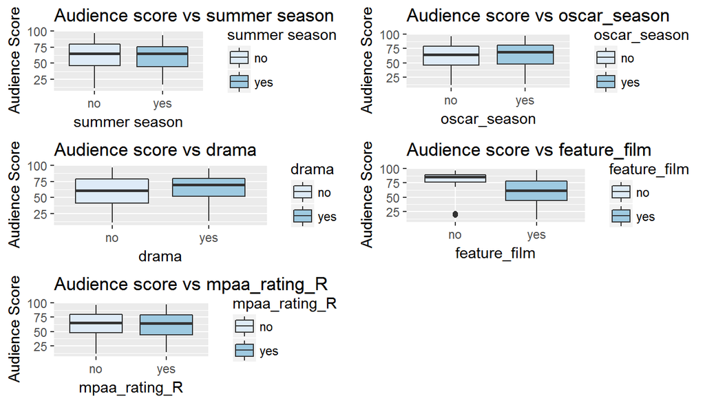

```r
data.grouped <- gather(data.analysis, 'features', 'flag', 2:6)

p1 <- ggplot(data = data.analysis, aes(x = summer_season, y = audience_score, fill = summer_season)) +
      geom_boxplot() + ggtitle('Audience score vs summer season') + xlab('summer season') +
      ylab('Audience Score') + scale_fill_brewer(name = "summer season")

p2 <- ggplot(data = data.analysis, aes(x = oscar_season, y = audience_score, fill = oscar_season)) +
      geom_boxplot() + ggtitle('Audience score vs oscar_season') + xlab('oscar_season') +
      ylab('Audience Score') + scale_fill_brewer(name = "oscar_season")

p3 <- ggplot(data = data.analysis, aes(x = drama, y = audience_score, fill = drama)) + geom_boxplot() +
      ggtitle('Audience score vs drama') + xlab('drama') + ylab('Audience Score') +
      scale_fill_brewer(name = "drama")

p4 <- ggplot(data = data.analysis, aes(x = feature_film, y = audience_score, fill = feature_film)) +
      geom_boxplot() + ggtitle('Audience score vs feature_film') + xlab('feature_film') +
      ylab('Audience Score') + scale_fill_brewer(name = "feature_film")

p5 <- ggplot(data = data.analysis, aes(x = mpaa_rating_R, y = audience_score, fill = mpaa_rating_R)) +
      geom_boxplot() + ggtitle('Audience score vs mpaa_rating_R') + xlab('mpaa_rating_R') +
      ylab('Audience Score') + scale_fill_brewer(name = "mpaa_rating_R")

# arrange the previously created plots
grid.arrange(p1, p2, p3, p4, p5, ncol = 2)
```

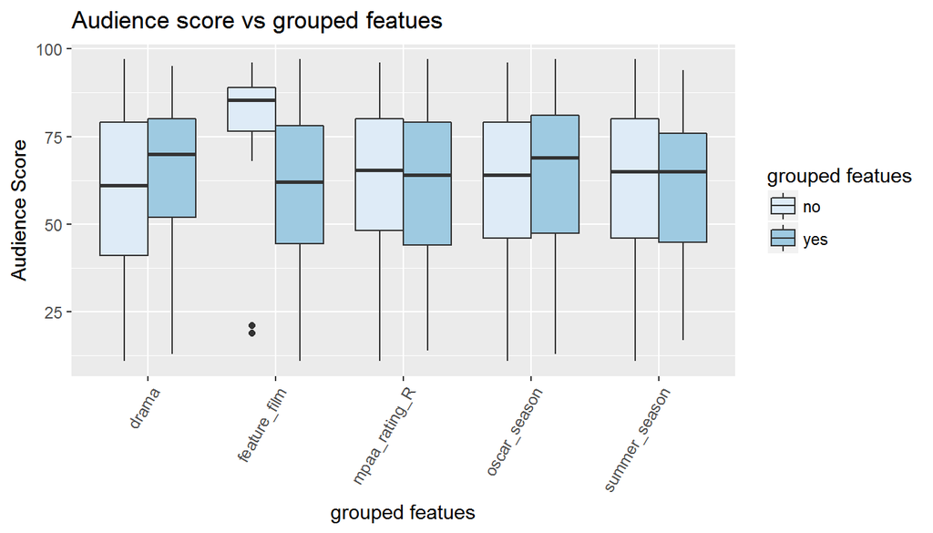

```r
 ggplot(data = data.grouped, aes(x = features, y = audience_score, fill = flag)) + geom_boxplot() +
      ggtitle('Audience score vs grouped featues') + xlab('grouped featues') + ylab('Audience Score') +
      theme(axis.text.x = element_text(angle = 60, hjust = 1)) +
      scale_fill_brewer(name = "grouped featues")
```

```r
data.grouped %>%
 group_by(features, flag) %>%
 summarise(mean = mean(audience_score), median = median(audience_score), min = min(audience_score),
           max = max(audience_score), IQR = IQR(audience_score))
```

```
Source: local data frame [10 x 7]
Groups: features [?]

        features  flag     mean median   min   max   IQR
           <chr> <chr>    <dbl>  <dbl> <dbl> <dbl> <dbl>
1          drama    no 59.73121   61.0    11    97 38.00
2          drama   yes 65.34754   70.0    13    95 28.00
3   feature_film    no 81.05000   85.5    19    96 12.50
4   feature_film   yes 60.46531   62.0    11    97 33.50
5  mpaa_rating_R    no 62.68944   65.5    11    96 31.75
6  mpaa_rating_R   yes 62.04255   64.0    14    97 35.00
7   oscar_season    no 61.81304   64.0    11    96 33.00
8   oscar_season   yes 63.68586   69.0    13    97 33.50
9  summer_season    no 62.60370   65.0    11    97 34.00
10 summer_season   yes 61.64634   65.0    17    94 31.25
```

Finally we will have a look at the other features used in the dataset. I left out the features as runtime, imdb_rating, imdb_num_votes, Above a selection of Density plots have been visualized. The plots show different features compared to the audience score.

[figure not shown]

```r
features <- c( 'audience_score', 'feature_film', 'drama', 'runtime', 'mpaa_rating_R', 'thtr_rel_year',
               'oscar_season', 'summer_season', 'imdb_rating', 'imdb_num_votes', 'critics_score',
               'best_pic_nom', 'best_pic_win', 'best_actor_win', 'best_actress_win', 'best_dir_win',
               'top200_box')

    # Create a new dataset to explicitely show dataset containing NA's
    data.model <- data[, features]

    # remove NA's
    data.model<- data.model[complete.cases(data.model), ]

    p1 <- ggplot(data.model, aes(audience_score, fill = feature_film))
    p1 <- p1 + geom_density(size=1, colour="darkgreen") + labs(title = "Dist. of audience score vs. feature_film") +
               labs(x = "feature film", y = "Density")

    p2 <- ggplot(data.model, aes(audience_score, fill = drama))
    p2 <- p2 + geom_density (alpha = 0.2) + labs(title = "Dist. of audience score vs. drama") +
               labs(x = "drama", y = "Density")

    p3 <- ggplot(data.model, aes(audience_score, fill = top200_box))
    p3 <- p3 + geom_density (alpha = 0.2) + labs(title = "Dist. of audience score vs. top200_box") +
               labs(x = "top200 box", y = "Density")

    p4 <- ggplot(data.model, aes(audience_score, fill = oscar_season))
    p4 <- p4 + geom_density(size=1, colour="darkgreen") + labs(title = "Dist. of audience score vs. oscar_season") +
               labs(x = "oscar season", y = "Density")

    p5 <- ggplot(data.model, aes(audience_score, fill = summer_season))
    p5 <- p5 + geom_density (alpha = 0.2) + labs(title = "Dist. of audience score vs. summer_season") +
               labs(x = "summer season", y = "Density")

    p6 <- ggplot(data.model, aes(audience_score, fill = best_pic_nom))
    p6  <- p6 + geom_density (alpha = 0.2) + labs(title = "Dist. of audience score vs. best_pic_nom") +
                labs(x = "best pic nom", y = "Density")

    p7 <- ggplot(data.model, aes(audience_score, fill = best_pic_win))
    p7 <- p7 + geom_density(size=1, colour="darkgreen") + labs(title = "Dist. of audience score vs. best pic win") +
               labs(x = "best pic win", y = "Density")

    p8 <- ggplot(data.model, aes(audience_score, fill = best_actor_win))
    p8 <- p8 + geom_density (alpha = 0.2) + labs(title = "Dist. of audience score vs. best_actor_win") +
               labs(x = "best actor win", y = "Density")

    p9 <- ggplot(data.model, aes(audience_score, fill = best_dir_win))
    p9 <- p9 + geom_density (alpha = 0.2) + labs(title = "Dist. of audience score vs. best_dir_win") +
               labs(x = "best dir win", y = "Density")

    p10 <- ggplot(data.model, aes(audience_score, fill = best_actress_win))
    p10 <- p10 + geom_density (alpha = 0.2) + labs(title = "Dist. of audience score vs. best_actress_win") +
                 labs(x = "best actress win", y = "Density")

    grid.arrange(p1, p2, p3, p4, p5, p6, p7, p8, p9, p10, ncol = 2)
```

## Hypothesis Testing

We will conduct a Bayesian hypothesis test by calculating a Bayes factor for each feature. The following hypothesis is meant to be generic and needs to be adjusted for each individual feature (feature_film, drama, mpaa_rating_R, oscar_season and summer_season). We assigned a uniform prior and use a ‘two sided’ direction for each analysis. I’ll just print on of the summaries to indicate the information which is contained. All others will be suppressed to save some space. Enable the params - show_res and show_summ by setting the value to TRUE.

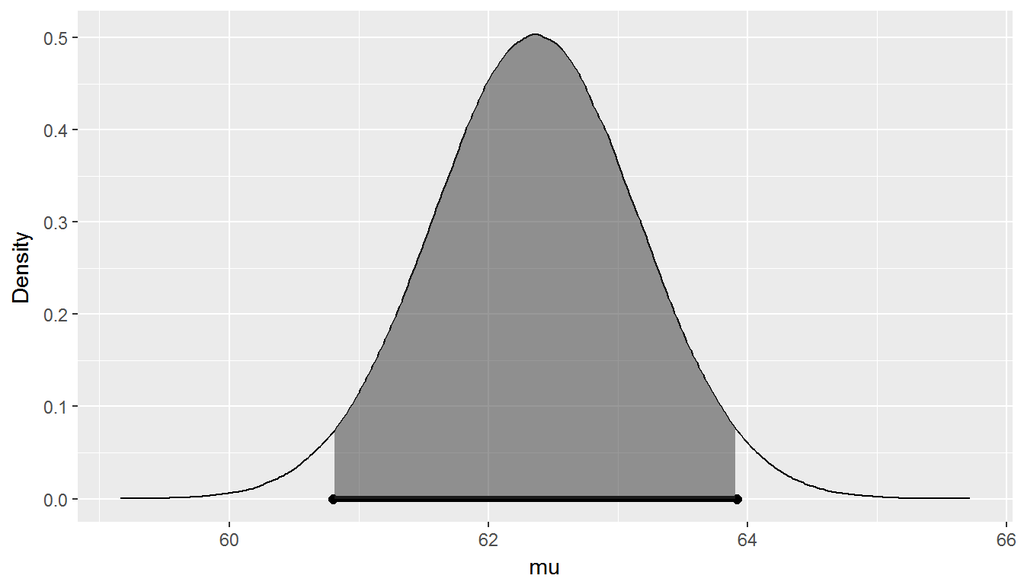

```r
bayes_inference(y = audience_score, data = data.analysis, cred_level = 0.95, statistic = "mean", type = "ci", null = 0, show_res = FALSE, show_summ = FALSE)
```

```r
bayes_inference(x = feature_film, y = audience_score, data = data.analysis, cred_level = 0.95, hypothesis_prior = c(0.5, 0.5), statistic = "mean", type = "ht", null = 0, alternative = 'twosided', show_res = TRUE, show_summ = TRUE)
```

```
Response variable: numerical, Explanatory variable: categorical (2 levels)
n_no = 60, y_bar_no = 81.05, s_no = 13.5764
n_yes = 591, y_bar_yes = 60.4653, s_yes = 19.824
(Assuming intrinsic prior on parameters)
Hypotheses:
H1: mu_no  = mu_yes
H2: mu_no != mu_yes

Priors:
P(H1) = 0.5
P(H2) = 0.5

Results:
BF[H2:H1] = 4.221452e+13
P(H1|data) = 0
P(H2|data) = 1
```

[figure not shown]

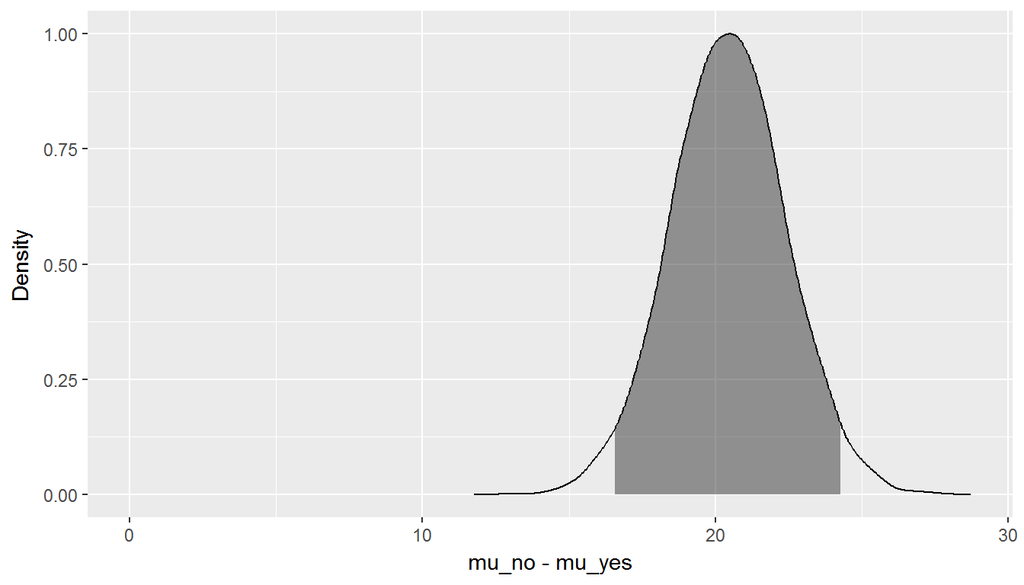

```r
bayes_inference(x = feature_film, y = audience_score, data = data.analysis, cred_level = 0.95, hypothesis_prior = c(0.5, 0.5), statistic = "mean", type = "ht", null = 0, alternative = 'twosided', show_res = FALSE, show_summ = FALSE )
```

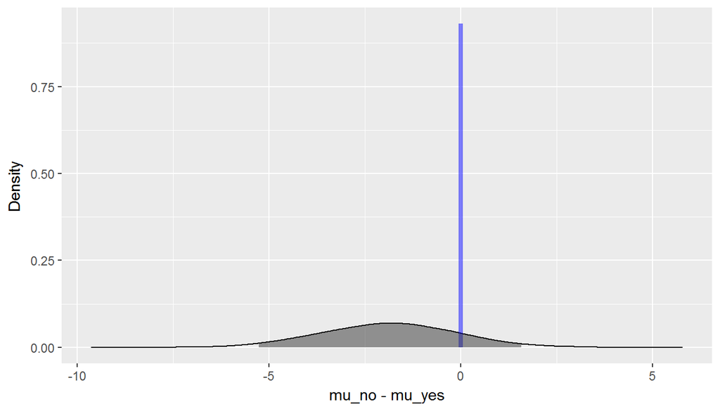

```r
bayes_inference(x = oscar_season, y = audience_score, data = data.analysis, cred_level = 0.95, hypothesis_prior = c(0.5, 0.5), statistic = "mean", type = "ht", null = 0, alternative = 'twosided', show_res = FALSE, show_summ = FALSE)
```

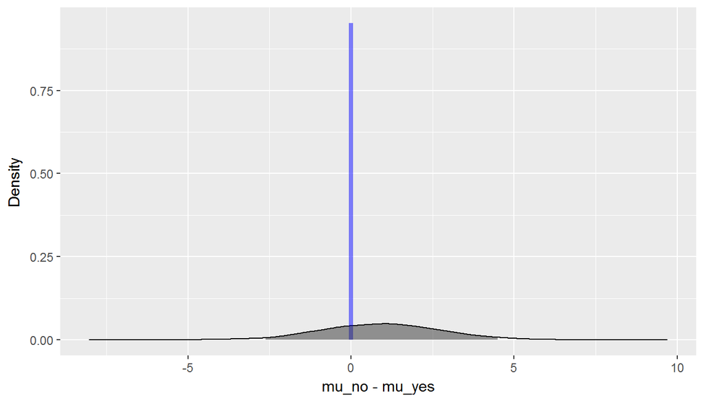

```r
bayes_inference(x = summer_season, y = audience_score, data = data.analysis, cred_level = 0.95, hypothesis_prior = c(0.5, 0.5), statistic = "mean", type = "ht", null = 0, alternative = 'twosided', show_res = FALSE, show_summ = FALSE)
```

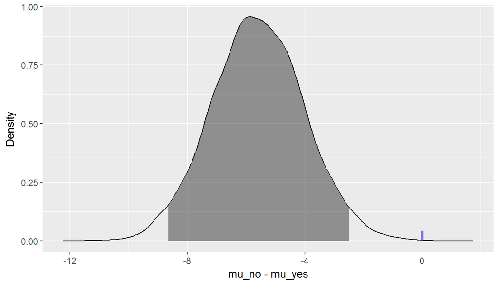

```r
bayes_inference(x = drama, y = audience_score, data = data.analysis, cred_level = 0.95, hypothesis_prior = c(0.5, 0.5), statistic = "mean", type = "ht", null = 0, alternative = 'twosided', show_res = FALSE, show_summ = FALSE)
```

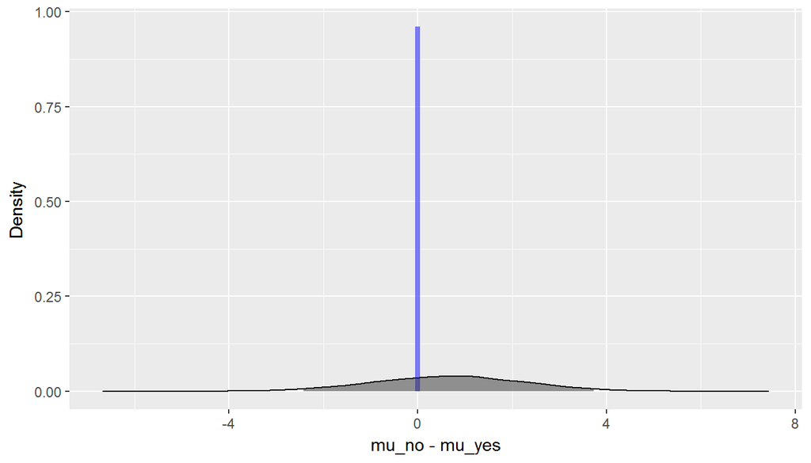

```r
bayes_inference(x = mpaa_rating_R, y = audience_score, data = data.analysis, cred_level = 0.95, hypothesis_prior = c(0.5, 0.5), statistic = "mean", type = "ht", null = 0, alternative = 'twosided', show_res = FALSE, show_summ = FALSE)
```